# Project 1

Peifeng Hong ph2534

## What is the difference of inaugural speeches according to approval rate in election?

The election of president in US is a big event for American people. During the voting, the presidents have to try their best to attract the voters and get as much vote as possible.

After the vote, there are several situation: A nominee is outstanding and has most of the vote, which means he collect a higher rate of the total votes. And here an analysis between the rate of earing votes and the winner’s inaugural speech is made.

# Step 0: check and install needed packages. Load the libraries and functions.

```r
packages.used=c("rvest", "tibble", "qdap",
                "sentimentr", "gplots", "dplyr",
                "tm", "syuzhet", "factoextra",
                "beeswarm", "scales", "RColorBrewer",
                "RANN", "tm", "topicmodels")

# check packages that need to be installed.
packages.needed=setdiff(packages.used,
                        intersect(installed.packages()[,1],
                                  packages.used))
# install additional packages
if(length(packages.needed)>0){
  install.packages(packages.needed, dependencies = TRUE)
}

# load packages
library("rvest")
library("tibble")
library("qdap")
library("sentimentr")
library("gplots")
library("dplyr")
library("tm")
library("syuzhet")
library("factoextra")
library("beeswarm")
library("scales")
library("RColorBrewer")
library("RANN")
library("tm")
library("topicmodels")

source("../lib/plotstacked.R")
source("../lib/speechFuncs.R")
```

# Step 1: Data harvest

Scrap inaugural address URLs from http://www.presidency.ucsb.edu/.

Following the example of [Jerid Francom](https://francojc.github.io/2015/03/01/web-scraping-with-rvest-in-r/), we used [Selectorgadget](http://selectorgadget.com/) to choose the links we would like to scrap.

For this project, we selected all inaugural addresses of past presidents for our textual analysis of presidential speeches as well as the election results by Electoral College margin from Wiki(https://en.wikipedia.org/wiki/List_of_United_States_presidential_elections_by_Electoral_College_margin).

```r
### Inauguaral speeches
main.page <- read_html(x = "http://www.presidency.ucsb.edu/inaugurals.php")
# Get link URLs
# f.speechlinks is a function for extracting links from the list of speeches.
inaug=f.speechlinks(main.page)

inaug=inaug[-nrow(inaug),] # remove the last line, irrelevant due to error.

#list of speech from <http://www.presidency.ucsb.edu/>
inaug.list=read.csv("../data/inauglist.csv", stringsAsFactors = FALSE)

#list of electoral resulte

result.list = read.csv("../data/election result.csv",stringsAsFactors = FALSE)

percentage <- result.list$Percentage
margin <- result.list$Normalized.victory.margin
```

prepare all the data into one dataset

```r
speech.list=inaug.list
speech.list$type=rep("inaug", nrow(inaug.list))
speech.list$percentage <- percentage
speech.list$margin <- margin
speech.url=inaug
speech.list=cbind(speech.list, speech.url)
```

using [Selectorgadget](http://selectorgadget.com/) to scrap the full speech.

```r
# Loop over each row in speech.list
speech.list$fulltext=NA
for(i in seq(nrow(speech.list))) {
  text <- read_html(speech.list$urls[i]) %>% # load the page
    html_nodes(".displaytext") %>% # isloate the text
    html_text() # get the text
  speech.list$fulltext[i]=text
  # Create the file name
  filename <- paste0("../data/fulltext/",
                     speech.list$type[i],
                     speech.list$File[i], "-",
                     speech.list$Term[i], ".txt")
  sink(file = filename) %>% # open file to write
  cat(text)  # write the file
  sink() # close the file
}
```

```r
sentence.list=NULL
for(i in 1:nrow(speech.list)){
  sentences=sent_detect(speech.list$fulltext[i],
                        endmarks = c("?", ".", "!", "|",";"))
  if(length(sentences)>0){
    emotions=get_nrc_sentiment(sentences)
    word.count=word_count(sentences)
    # colnames(emotions)=paste0("emo.", colnames(emotions))
    # in case the word counts are zeros?
    emotions=diag(1/(word.count+0.01))%*%as.matrix(emotions)
    sentence.list=rbind(sentence.list,
                        cbind(speech.list[i,-ncol(speech.list)],
                              sentences=as.character(sentences),
                              word.count,
                              emotions,
                              sent.id=1:length(sentences)
                              )
    )
  }

sentence.list=
  sentence.list%>%
  filter(!is.na(word.count))
}
```

We can see high margin and high percentage goes to same president. Then we can select a group of presidents who has high approval rate as well as low approval rate.

```r
orderbypercent <- order(speech.list$percentage)
orderbymargin <- order(speech.list$margin)
head(speech.list[orderbypercent,c(1,9)],10)
```

```
##            ï..President percentage
## 10    John Quincy Adams     0.3218
## 23  Rutherford B. Hayes     0.5014
## 54       George W. Bush     0.5037
## 3            John Adams     0.5145
## 33       Woodrow Wilson     0.5217
## 4      Thomas Jefferson     0.5290
## 55       George W. Bush     0.5316
## 25 Grover Cleveland - I     0.5461
## 48         Jimmy Carter     0.5520
## 46        Richard Nixon     0.5595
```

```r
tail(speech.list[orderbypercent,c(1,9)],10)
```

```
##             ï..President percentage
## 45     Lyndon B. Johnson     0.9033
## 49         Ronald Reagan     0.9089
## 20       Abraham Lincoln     0.9099
## 5       Thomas Jefferson     0.9205
## 47         Richard Nixon     0.9665
## 50         Ronald Reagan     0.9758
## 38 Franklin D. Roosevelt     0.9849
## 9           James Monroe     0.9957
## 1      George Washington     1.0000
## 2      George Washington     1.0000
```

```r
head(speech.list[orderbymargin,c(1,10)],10)
```

```
##            ï..President margin
## 4      Thomas Jefferson  0.000
## 10    John Quincy Adams  0.000
## 23  Rutherford B. Hayes  0.003
## 54       George W. Bush  0.009
## 3            John Adams  0.029
## 33       Woodrow Wilson  0.043
## 55       George W. Bush  0.063
## 25 Grover Cleveland - I  0.092
## 48         Jimmy Carter  0.104
## 46        Richard Nixon  0.119
```

```r
tail(speech.list[orderbymargin,c(1,10)],10)
```

```
##             ï..President margin
## 45     Lyndon B. Johnson  0.807
## 49         Ronald Reagan  0.818
## 20       Abraham Lincoln  0.820
## 5       Thomas Jefferson  0.841
## 47         Richard Nixon  0.933
## 50         Ronald Reagan  0.952
## 38 Franklin D. Roosevelt  0.970
## 9           James Monroe  0.991
## 1      George Washington  1.000
## 2      George Washington  1.000
```

```r
Lpertpresident <- speech.list[orderbypercent[1:15],2]
Hpertpresident <- speech.list[orderbypercent[39:58],2]
```

# Step 2: basic analysis –length of words

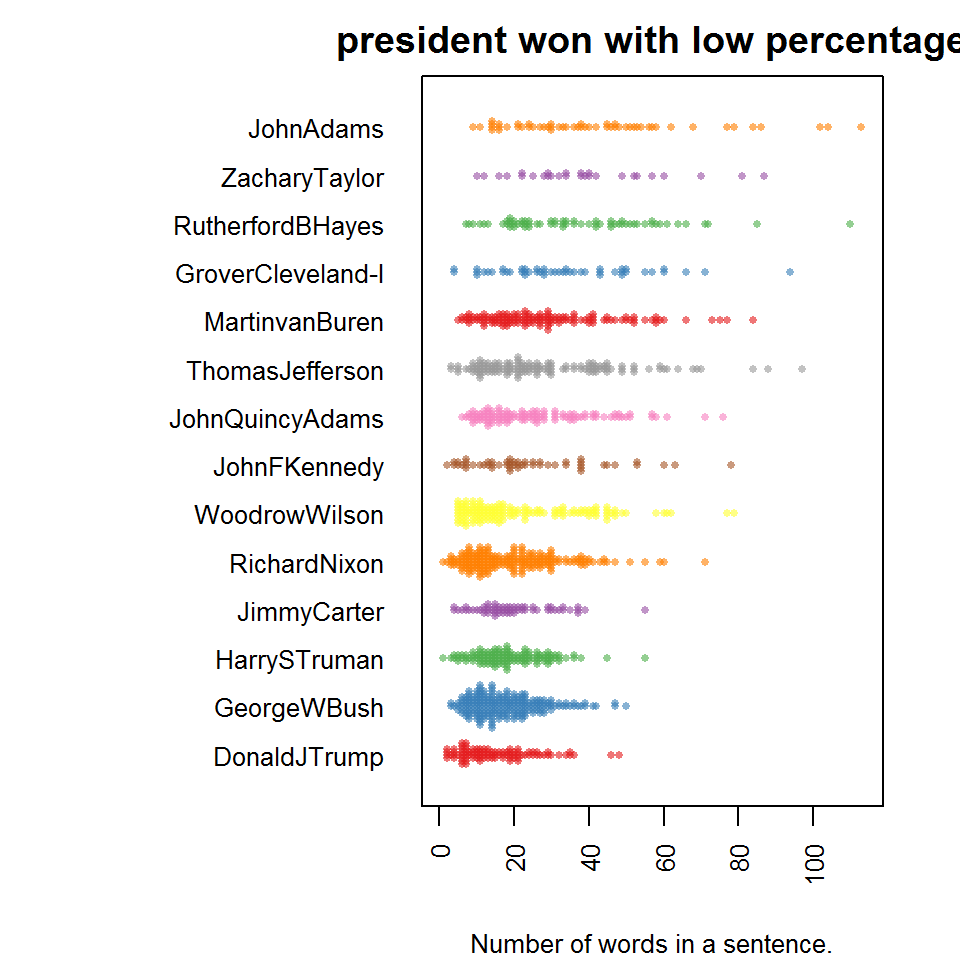

```r
par(mar=c(4, 11, 2, 2))



funcofLOA <- function(sel.comparison,mainvar){
  sentence.list.sel=filter(sentence.list,File%in%sel.comparison)
  sentence.list.sel$File=factor(sentence.list.sel$File)

  sentence.list.sel$FileOrdered=reorder(sentence.list.sel$File,
                                    sentence.list.sel$word.count,
                                    mean,
                                    order=T)

  beeswarm(word.count~FileOrdered,
           data=sentence.list.sel,
           horizontal = TRUE,
           pch=16, col=alpha(brewer.pal(9, "Set1"), 0.6),
           cex=0.55, cex.axis=0.8, cex.lab=0.8,
           spacing=5/nlevels(sentence.list.sel$FileOrdered),
           las=2, xlab="Number of words in a sentence.", ylab="",
           main = mainvar)
}

funcofLOA(Lpertpresident,"president won with low percentage")
```

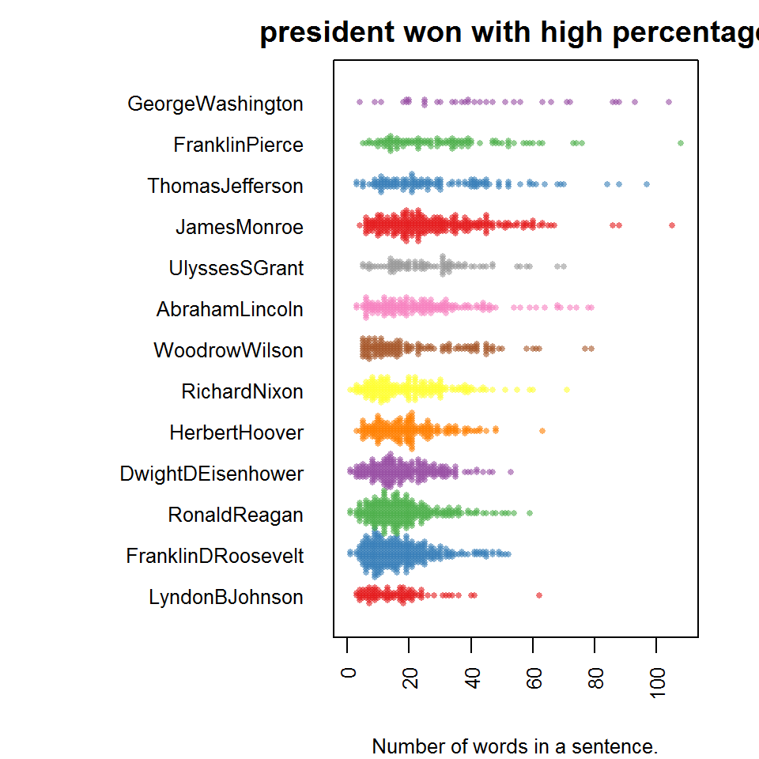

```r
funcofLOA(Hpertpresident,"president won with high percentage")
```

# Step 2: sentence visualization

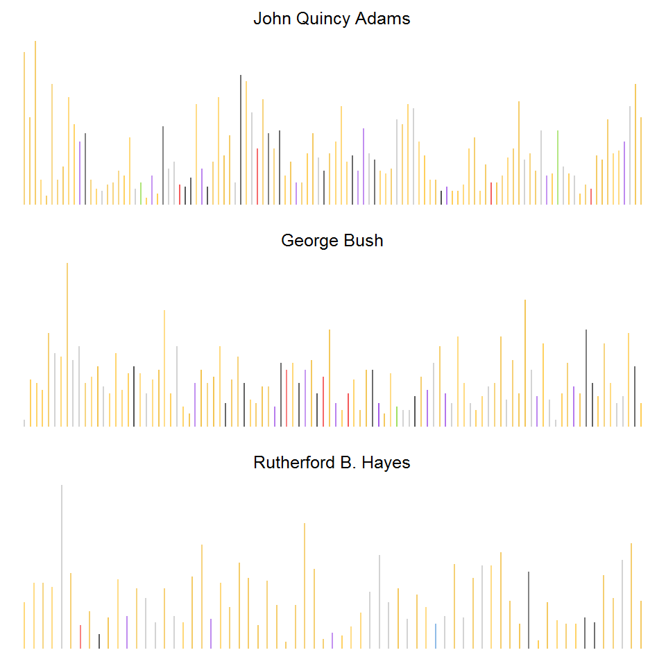

```r
par(mfrow=c(3,1), mar=c(1,0,2,0), bty="n", xaxt="n", yaxt="n", font.main=1)

f.plotsent.len(In.list=sentence.list, InFile="JohnQuincyAdams",
               InType="inaug",InTerm=1,President = "John Quincy Adams")

f.plotsent.len(In.list=sentence.list, InFile="GeorgeWBush",
               InType="inaug",InTerm=1,President = "George Bush")

f.plotsent.len(In.list=sentence.list, InFile="RutherfordBHayes",
               InType="inaug",InTerm=1,President = "Rutherford B. Hayes")
```

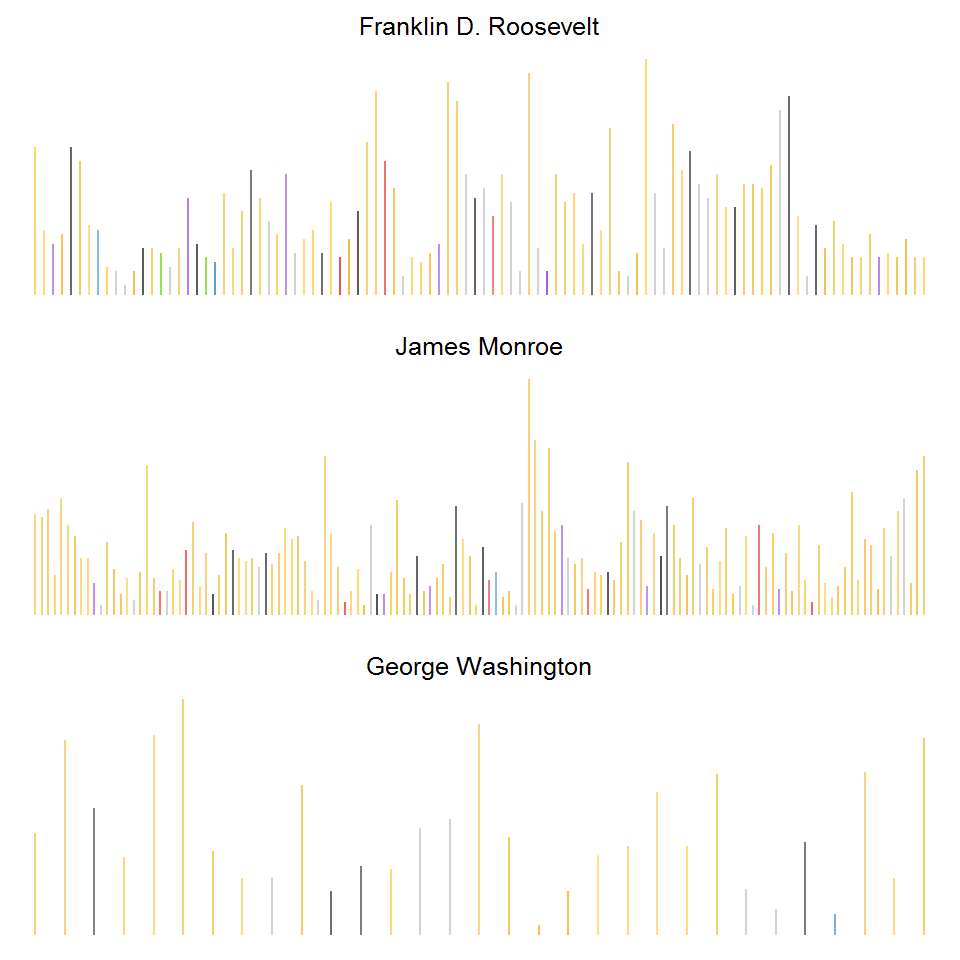

```r
f.plotsent.len(In.list=sentence.list, InFile="FranklinDRoosevelt",
               InType="inaug",InTerm=1,President = "Franklin D. Roosevelt")

f.plotsent.len(In.list=sentence.list, InFile="JamesMonroe",
               InType="inaug",InTerm=1,President = "James Monroe")


f.plotsent.len(In.list=sentence.list, InFile="GeorgeWashington",
               InType="inaug",InTerm=1,President = "George Washington")
```

The figures listed above show some example of pattern from two types of president.

# Step 2: Emotion analysis

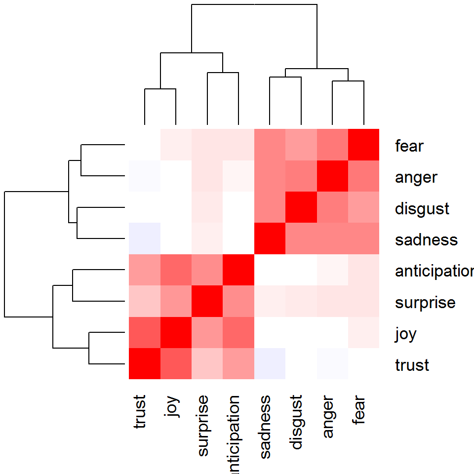

```r
heatmap.2(cor(sentence.list%>%filter(type=="inaug")%>%select(anger:trust)),
          scale = "none",
          col = bluered(100), , margin=c(6, 6), key=F,
          trace = "none", density.info = "none")
```

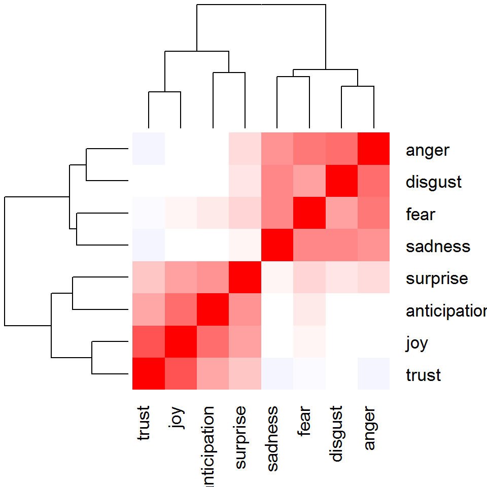

```r
heatmap.2(cor(sentence.list%>%filter(File%in%Hpertpresident)%>%select(anger:trust)),
          scale = "none",
          col = bluered(100), , margin=c(6, 6), key=F,
          trace = "none", density.info = "none")
```

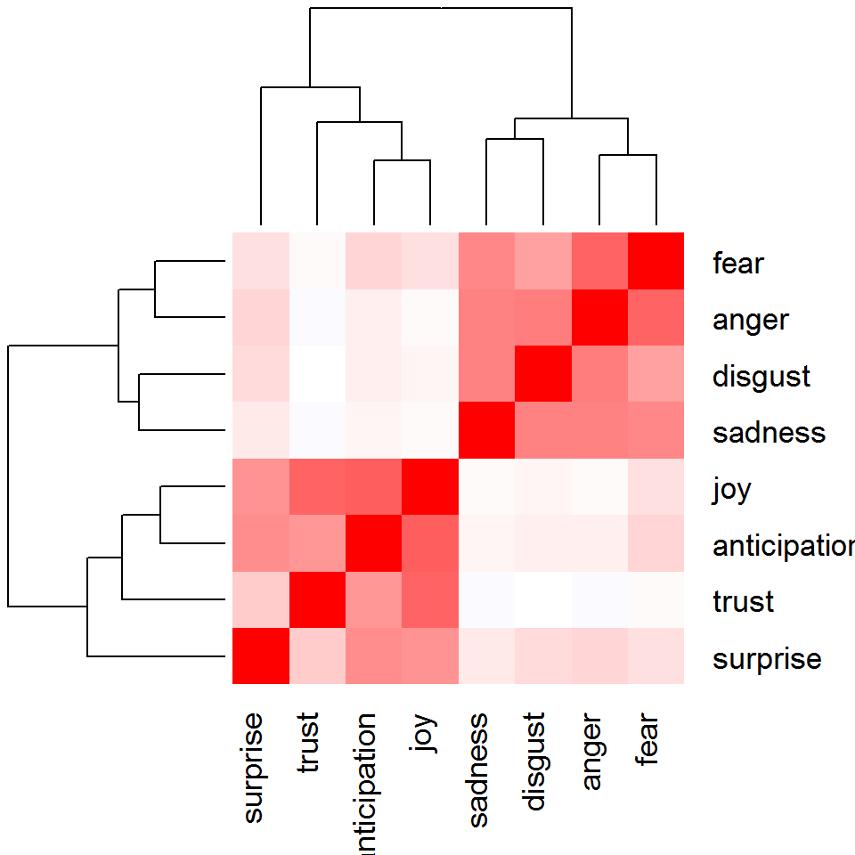

```r
heatmap.2(cor(sentence.list%>%filter(File%in%Lpertpresident)%>%select(anger:trust)),
          scale = "none",
          col = bluered(100), , margin=c(6, 6), key=F,
          trace = "none", density.info = "none")
```

The heatmap show difference in the mixed feeling of the speech. Presidents with high approval rate mixed anger with disgust, and joy with trust. Presidents with low approval rate, yet, mixed anger with fear, joy with anticipation. Probably, presidents with high approval rate is happy because people voted him. They are angry about the disgusting hardship they faced. And presidents with low approval rate were happy because they won from a tough fight and wanted to make a difference, they were angry and fear about people who did not support them.

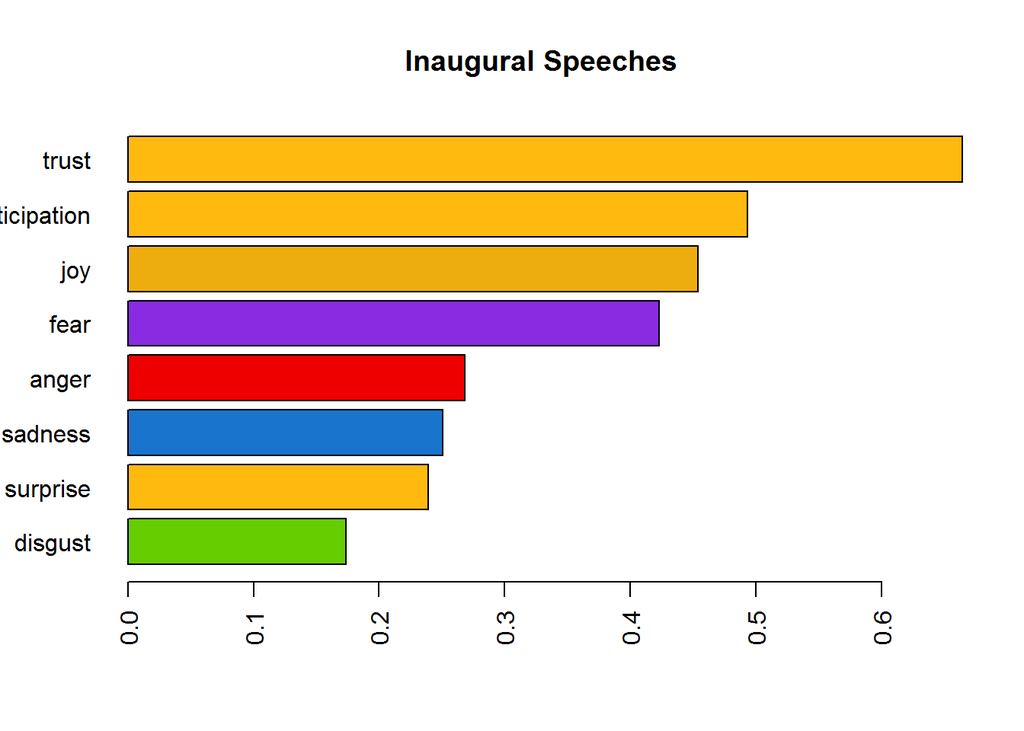

```r
emo.means=colMeans(select(sentence.list, anger:trust)>0.01)
col.use=c("red2", "darkgoldenrod1",
            "chartreuse3", "blueviolet",
            "darkgoldenrod2", "dodgerblue3",
            "darkgoldenrod1", "darkgoldenrod1")
barplot(emo.means[order(emo.means)], las=2, col=col.use[order(emo.means)], horiz=T, main="Inaugural Speeches")
```

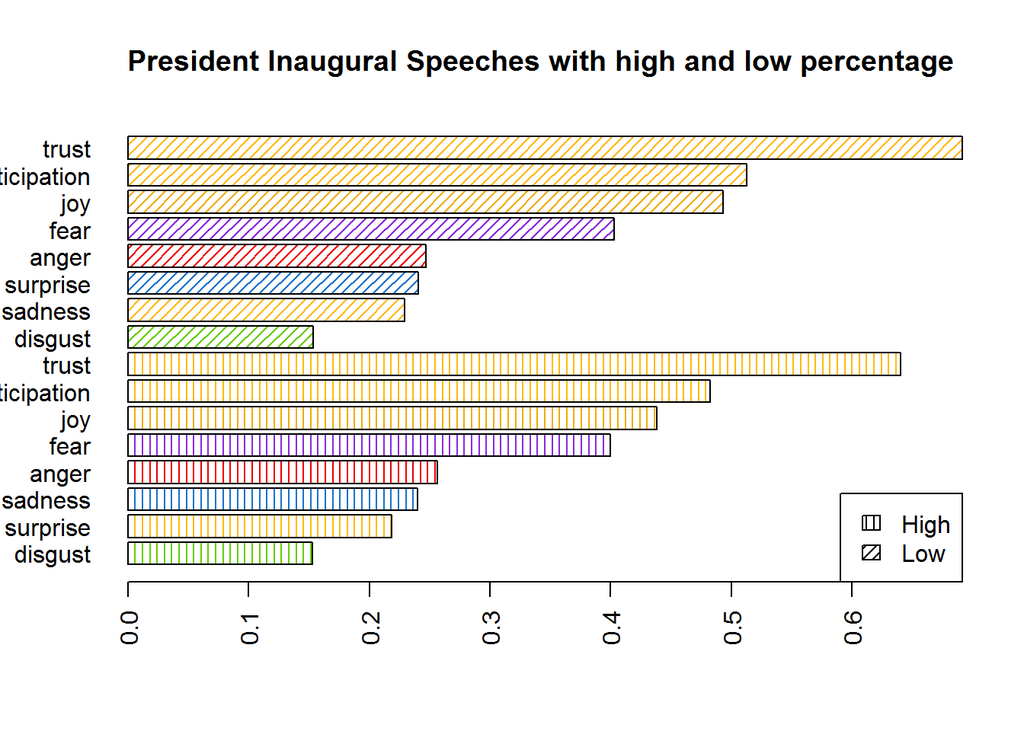

```r
emo.means1=colMeans(sentence.list%>%filter(File%in%Hpertpresident)%>%select(anger:trust)>0.01)

emo.means2=colMeans(sentence.list%>%filter(File%in%Lpertpresident)%>%select(anger:trust)>0.01)
col.use=c("red2", "darkgoldenrod1",
            "chartreuse3", "blueviolet",
            "darkgoldenrod2", "dodgerblue3",
            "darkgoldenrod1", "darkgoldenrod1")
barplot(c(emo.means1[order(emo.means1)],emo.means2[order(emo.means2)]), las=2,angle=rep(c(90,45),each = 8),density=rep(c(20),16), col=col.use[order(emo.means)], horiz=T,beside = T,main="President Inaugural Speeches with high and low percentage")
legend("bottomright", c("High","Low"), angle = c(90,45),density = 20)
```

We use bar plot to compare the feeling in the speech between two type of presidents. President with lower percentage, the sadness in speech is less than surprise feeling, which is different from the predsident with high percentage as well as the average. We should also notice that president with high percentage has less joy and trust in their speech compared with the president with low percentage.

# Step 3: sentiment analysis — Topic modeling

Topic modelling on president speech with low approval rate

```r
S1 <-sentence.list%>%filter(File%in%Lpertpresident)

corpus.list=S1[2:(nrow(S1)-1), ]
sentence.pre=S1$sentences[1:(nrow(S1)-2)]
sentence.post=S1$sentences[3:(nrow(S1)-1)]
corpus.list$snipets=paste(sentence.pre, corpus.list$sentences, sentence.post, sep=" ")
rm.rows=(1:nrow(corpus.list))[corpus.list$sent.id==1]
rm.rows=c(rm.rows, rm.rows-1)
corpus.list=corpus.list[-rm.rows, ]


docs <- Corpus(VectorSource(corpus.list$snipets))
docs <-tm_map(docs,content_transformer(tolower))
docs <- tm_map(docs, removePunctuation)
docs <- tm_map(docs, removeNumbers)
docs <- tm_map(docs, removeWords, stopwords("english"))
docs <- tm_map(docs, stripWhitespace)
docs <- tm_map(docs,stemDocument)


dtm <- DocumentTermMatrix(docs)
#convert rownames to filenames#convert rownames to filenames
rownames(dtm) <- paste(corpus.list$type, corpus.list$File,
                         corpus.list$Term, corpus.list$sent.id, sep="_")

rowTotals <- apply(dtm , 1, sum) #Find the sum of words in each Document

dtm  <- dtm[rowTotals> 0, ]
corpus.list=corpus.list[rowTotals>0, ]


L_corpus.list <- corpus.list

#Set parameters for Gibbs sampling
burnin <- 1000
iter <- 1000
thin <- 500
seed <-list(2003,5,63,100001,765)
nstart <- 5
best <- TRUE

#Number of topics
k <- 15

#Run LDA using Gibbs sampling
L_ldaOut <-LDA(dtm, k, method="Gibbs", control=list(nstart=nstart,
                                                 seed = seed, best=best,
                                                 burnin = burnin, iter = iter,
                                                 thin=thin))
#write out results
#docs to topics
L_ldaOut.topics <- as.matrix(topics(L_ldaOut))
table(c(1:k, L_ldaOut.topics))
```

```
##
##   1   2   3   4   5   6   7   8   9  10  11  12  13  14  15
## 122  94  94  97  91 108  96  92  88  60  82  96 107 116  94
```

```r
write.csv(L_ldaOut.topics,file=paste("../output/LDAGibbs",k,"L_DocsToTopics.csv"))

#top 6 terms in each topic
L_ldaOut.terms <- as.matrix(terms(L_ldaOut,20))
write.csv(L_ldaOut.terms,file=paste("../output/LDAGibbs",k,"L_TopicsToTerms.csv"))

#probabilities associated with each topic assignment
L_topicProbabilities <- as.data.frame(L_ldaOut@gamma)
write.csv(L_topicProbabilities,file=paste("../output/LDAGibbs",k,"L_TopicProbabilities.csv"))

L_terms.beta=L_ldaOut@beta
L_terms.beta=scale(L_terms.beta)
L_topics.terms=NULL
for(i in 1:k){
  L_topics.terms=rbind(L_topics.terms, L_ldaOut@terms[order(L_terms.beta[i,], decreasing = TRUE)[1:7]])
}

L_topics.terms
```

```
##       [,1]        [,2]       [,3]          [,4]         [,5]
##  [1,] "fellow"    "oath"     "ago"         "chief"      "deep"
##  [2,] "recommend" "expens"   "expenditur"  "revenu"     "account"
##  [3,] "democrat"  "plan"     "affect"      "number"     "aspir"
##  [4,] "duti"      "often"    "predecessor" "assembl"    "assist"
##  [5,] "simpl"     "structur" "initi"       "indispens"  "hard"
##  [6,] "freedom"   "mankind"  "though"      "reflect"    "came"
##  [7,] "children"  "alter"    "women"       "effici"     "vision"
##  [8,] "reason"    "truth"    "exact"       "enforc"     "taxat"
##  [9,] "sourc"     "evid"     "embarrass"   "instanc"    "anticip"
## [10,] "virtu"     "gratitud" "command"     "anyth"      "glori"
## [11,] "sever"     "appoint"  "conclus"     "vari"       "behalf"
## [12,] "union"     "feder"    "legisl"      "accomplish" "section"
## [13,] "heart"     "ocean"    "beauti"      "stir"       "dedic"
## [14,] "make"      "courag"   "quiet"       "tell"       "confront"
```

[output cut: 17 more lines]

```r
L_ldaOut.terms
```

```
##       Topic 1   Topic 2     Topic 3      Topic 4         Topic 5
##  [1,] "time"    "state"     "peopl"      "duti"          "peac"
##  [2,] "citizen" "among"     "nation"     "shall"         "nation"
##  [3,] "first"   "may"       "must"       "countri"       "new"
##  [4,] "presid"  "foreign"   "free"       "faith"         "great"
##  [5,] "histori" "limit"     "effort"     "honor"         "world"
##  [6,] "today"   "war"       "secur"      "confid"        "respons"
##  [7,] "justic"  "improv"    "unit"       "trust"         "polici"
##  [8,] "stand"   "intern"    "now"        "servic"        "just"
##  [9,] "share"   "remain"    "countri"    "execut"        "need"
## [10,] "still"   "mind"      "believ"     "success"       "home"
## [11,] "centuri" "commerc"   "mean"       "may"           "let"
## [12,] "place"   "land"      "achiev"     "expect"        "better"
## [13,] "just"    "congress"  "resourc"    "call"          "act"
## [14,] "use"     "effect"    "benefit"    "whose"         "abroad"
```

[output cut: 48 more lines]

```r
L_topics.hash = c("history","state","economics","duty","peace","freedom","life","justice","patriot","govern","party","legislation","american","future","help")

L_corpus.list$ldatopic=as.vector(L_ldaOut.topics)
L_corpus.list$ldahash=L_topics.hash[L_ldaOut.topics]

colnames(L_topicProbabilities)=L_topics.hash
L_corpus.list.df=cbind(L_corpus.list, L_topicProbabilities)


L_topic.plot=c(1, 2, 3, 5, 12, 13)
#history  #state  #economics  #peace  #legislation  #american
print(L_topics.hash[L_topic.plot])
```

```
## [1] "history"     "state"       "economics"   "peace"       "legislation"
## [6] "american"
```

```r
par(mfrow=c(5, 1), mar=c(1,1,2,0), bty="n", xaxt="n", yaxt="n")

speech.df=tbl_df(L_corpus.list.df)%>%filter(File=="JimmyCarter", type=="inaug", Term==1)%>%select(sent.id, history:help)
speech.df=as.matrix(speech.df)
speech.df[,-1]=replace(speech.df[,-1], speech.df[,-1]<1/15, 0.001)
speech.df[,-1]=f.smooth.topic(x=speech.df[,1], y=speech.df[,-1])
plot.stacked(speech.df[,1], speech.df[,L_topic.plot+1],
             xlab="Sentences", ylab="Topic share", main="Jimmy Carter, inaugural Speeches")
```

```
## [1] 0.06986702 0.13973403 0.20960105 0.27946806 0.34933508 0.41920209
```

```r
speech.df=tbl_df(L_corpus.list.df)%>%filter(File=="WoodrowWilson", type=="inaug", Term==1)%>%select(sent.id, history:help)
speech.df=as.matrix(speech.df)
speech.df[,-1]=replace(speech.df[,-1], speech.df[,-1]<1/15, 0.001)
speech.df[,-1]=f.smooth.topic(x=speech.df[,1], y=speech.df[,-1])
plot.stacked(speech.df[,1], speech.df[,L_topic.plot+1],
             xlab="Sentences", ylab="Topic share", main="Woodrow Wilson, inaugural Speeches")
```

```
## [1] 0.05140683 0.10281365 0.15422048 0.20562731 0.25703414 0.30844096
```

```r
speech.df=tbl_df(L_corpus.list.df)%>%filter(File=="GeorgeWBush", type=="inaug", Term==1)%>%select(sent.id, history:help)
speech.df=as.matrix(speech.df)
speech.df[,-1]=replace(speech.df[,-1], speech.df[,-1]<1/15, 0.001)
speech.df[,-1]=f.smooth.topic(x=speech.df[,1], y=speech.df[,-1])
plot.stacked(speech.df[,1], speech.df[,L_topic.plot+1],
             xlab="Sentences", ylab="Topic share", main="George Bush, inaugural Speeches")
```

```
## [1] 0.05714454 0.11428909 0.17143363 0.22857818 0.28572272 0.34286727
```

```
## [1] 0.06608864 0.13217727 0.19826591 0.26435454 0.33044318 0.39653182
```

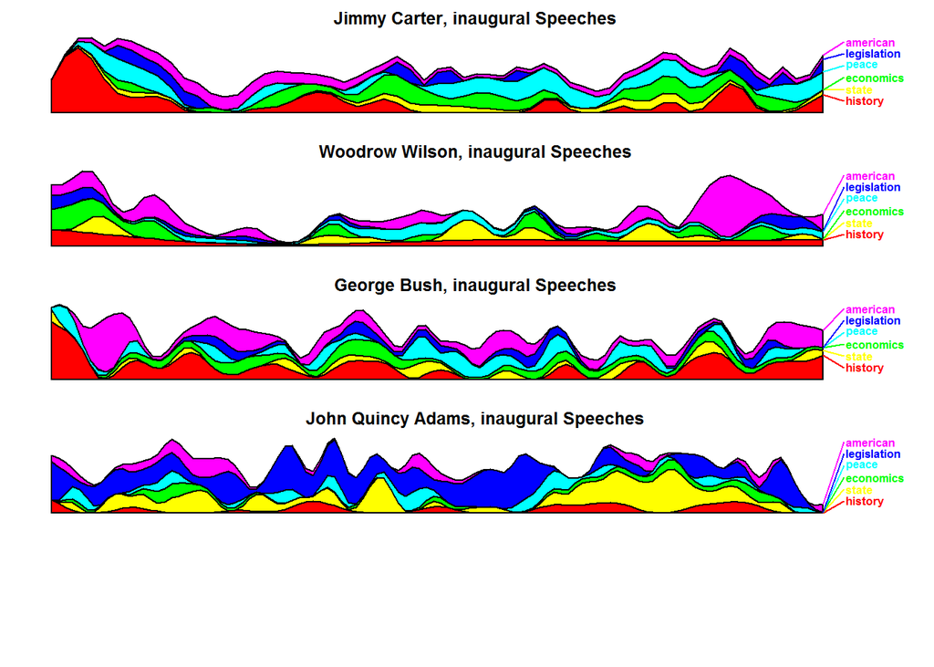

```r
speech.df=tbl_df(L_corpus.list.df)%>%filter(File=="JohnQuincyAdams", type=="inaug", Term==1)%>%select(sent.id, history:help)
speech.df=as.matrix(speech.df)
speech.df[,-1]=replace(speech.df[,-1], speech.df[,-1]<1/15, 0.001)
speech.df[,-1]=f.smooth.topic(x=speech.df[,1], y=speech.df[,-1])
plot.stacked(speech.df[,1], speech.df[,L_topic.plot+1],
             xlab="Sentences", ylab="Topic share", main="John Quincy Adams, inaugural Speeches")
```

Topic modelling on president speech with high approval rate

```r
S2 <-sentence.list%>%filter(File%in%Hpertpresident)

corpus.list=S2[2:(nrow(S2)-1), ]
sentence.pre=S2$sentences[1:(nrow(S2)-2)]
sentence.post=S2$sentences[3:(nrow(S2)-1)]
corpus.list$snipets=paste(sentence.pre, corpus.list$sentences, sentence.post, sep=" ")
rm.rows=(1:nrow(corpus.list))[corpus.list$sent.id==1]
rm.rows=c(rm.rows, rm.rows-1)
corpus.list=corpus.list[-rm.rows, ]


docs <- Corpus(VectorSource(corpus.list$snipets))
docs <-tm_map(docs,content_transformer(tolower))
docs <- tm_map(docs, removePunctuation)
docs <- tm_map(docs, removeNumbers)
docs <- tm_map(docs, removeWords, stopwords("english"))
docs <- tm_map(docs, stripWhitespace)
docs <- tm_map(docs,stemDocument)


dtm <- DocumentTermMatrix(docs)
#convert rownames to filenames#convert rownames to filenames
rownames(dtm) <- paste(corpus.list$type, corpus.list$File,
                         corpus.list$Term, corpus.list$sent.id, sep="_")

rowTotals <- apply(dtm , 1, sum) #Find the sum of words in each Document

dtm  <- dtm[rowTotals> 0, ]
corpus.list=corpus.list[rowTotals>0, ]

H_corpus.list <- corpus.list

#Set parameters for Gibbs sampling
burnin <- 1000
iter <- 1000
thin <- 500
seed <-list(2003,5,63,100001,765)
nstart <- 5
best <- TRUE

#Number of topics
k <- 15

#Run LDA using Gibbs sampling
H_ldaOut <-LDA(dtm, k, method="Gibbs", control=list(nstart=nstart,
                                                 seed = seed, best=best,
                                                 burnin = burnin, iter = iter,
                                                 thin=thin))
#write out results
#docs to topics
H_ldaOut.topics <- as.matrix(topics(H_ldaOut))
table(c(1:k, H_ldaOut.topics))
```

```
##
##   1   2   3   4   5   6   7   8   9  10  11  12  13  14  15
## 177 209 179 154 170 107 121 161 166 135 167 108 114  96 180
```